# Implementation Study Analysis

2024-03-15

# Background

The overall goal of this project is to reduce morbidity and mortality of sick children attending primary care facilities while supporting the rational and efficient use of diagnostics and medicines by healthcare providers. This study is focused on understanding the operational feasibility of multimodal pulse ox use in standard care. The results presented in this document describe several weeks of use of the Masimo pulse oximeter in primary care settings.

# Table 1: Patient demographic and household characteristics.

## Senegal

|  | Overall | Facility 1 | Facility 2 |
| --- | --- | --- | --- |
| N | 391 | 182 | 209 |
| **Demographic Characteristics** |  |  |  |
| Age Category: 2-59 months (%) | 367 (93.9) | 169 (92.9) | 198 (94.7) |
| Caregiver Relationship (%) |  |  |  |
| Community member | 1 ( 0.3) | 0 ( 0.0) | 1 ( 0.5) |
| Father only | 10 ( 2.6) | 3 ( 1.7) | 7 ( 3.4) |
| Grandfather only | 1 ( 0.3) | 0 ( 0.0) | 1 ( 0.5) |
| Grandmother only | 24 ( 6.2) | 14 ( 7.8) | 10 ( 4.8) |
| Mother and father | 5 ( 1.3) | 0 ( 0.0) | 5 ( 2.4) |
| Mother and grandmother | 4 ( 1.0) | 2 ( 1.1) | 2 ( 1.0) |
| Mother only | 331 (85.3) | 158 (87.8) | 173 (83.2) |
| Other family member | 8 ( 2.1) | 1 ( 0.6) | 7 ( 3.4) |
| Sibling | 4 ( 1.0) | 2 ( 1.1) | 2 ( 1.0) |
| Caregiver Age (mean (SD)) | 36.41 (101.69) | 32.86 (10.95) | 39.44 (138.26) |
| Maternal Education (highest level attended) (%) |  |  |  |
| Primary | 106 (31.4) | 71 (44.9) | 35 (19.4) |
| Post-Primary/Vocational | 0 ( 0.0) | 0 ( 0.0) | 0 ( 0.0) |
| Secondary | 71 (21.0) | 27 (17.1) | 44 (24.4) |
| Diploma/Certificate | 4 ( 1.2) | 3 ( 1.9) | 1 ( 0.6) |
| Bachelors degree or equivalent | 3 ( 0.9) | 1 ( 0.6) | 2 ( 1.1) |
| Masters degree or equivalent | 0 ( 0.0) | 0 ( 0.0) | 0 ( 0.0) |
| Other | 128 (37.9) | 56 (35.4) | 72 (40.0) |
| Never attended any formal schooling | 26 ( 7.7) | 0 ( 0.0) | 26 (14.4) |
| **Household Characteristics** |  |  |  |
| Household head (%) |  |  |  |
| Female | 1 ( 0.3) | 1 ( 0.6) | 0 ( 0.0) |
| Mother of sick child | 8 ( 2.1) | 2 ( 1.1) | 6 ( 3.0) |
| Grandmother (maternal) | 14 ( 3.7) | 4 ( 2.3) | 10 ( 5.0) |
| Grandmother (paternal) | 0 ( 0.0) | 0 ( 0.0) | 0 ( 0.0) |
| Other female | 250 (66.0) | 169 (95.5) | 81 (40.1) |

[output cut: 53 more lines]

## Tanzania

|  | Overall | Facility 1 | Facility 2 |
| --- | --- | --- | --- |
| N | 422 | 202 | 220 |
| **Demographic Characteristics** |  |  |  |
| Age Category: 2-59 months (%) | 403 (95.5) | 198 ( 98.0) | 205 (93.2) |
| Caregiver Relationship (%) |  |  |  |
| Community member | 0 ( 0.0) | 0 ( 0.0) | 0 ( 0.0) |
| Father only | 8 ( 1.9) | 0 ( 0.0) | 8 ( 3.6) |
| Grandfather only | 0 ( 0.0) | 0 ( 0.0) | 0 ( 0.0) |
| Grandmother only | 0 ( 0.0) | 0 ( 0.0) | 0 ( 0.0) |
| Mother and father | 25 ( 5.9) | 22 ( 10.9) | 3 ( 1.4) |
| Mother and grandmother | 2 ( 0.5) | 0 ( 0.0) | 2 ( 0.9) |
| Mother only | 385 (91.2) | 180 ( 89.1) | 205 (93.2) |
| Other family member | 2 ( 0.5) | 0 ( 0.0) | 2 ( 0.9) |
| Sibling | 0 ( 0.0) | 0 ( 0.0) | 0 ( 0.0) |
| Caregiver Age (mean (SD)) | 28.51 (5.58) | 28.30 (6.00) | 28.70 (5.16) |
| Maternal Education (highest level attended) (%) |  |  |  |
| Primary | 116 (28.2) | 40 ( 19.8) | 76 (36.2) |
| Post-Primary/Vocational | 30 ( 7.3) | 19 ( 9.4) | 11 ( 5.2) |
| Secondary | 135 (32.8) | 46 ( 22.8) | 89 (42.4) |
| Diploma/Certificate | 87 (21.1) | 66 ( 32.7) | 21 (10.0) |
| Bachelors degree or equivalent | 24 ( 5.8) | 19 ( 9.4) | 5 ( 2.4) |
| Masters degree or equivalent | 7 ( 1.7) | 7 ( 3.5) | 0 ( 0.0) |
| Other | 1 ( 0.2) | 0 ( 0.0) | 1 ( 0.5) |
| Never attended any formal schooling | 12 ( 2.9) | 5 ( 2.5) | 7 ( 3.3) |
| **Household Characteristics** |  |  |  |
| Household head (%) |  |  |  |
| Female | 16 ( 3.8) | 15 ( 7.4) | 1 ( 0.5) |
| Mother of sick child | 18 ( 4.3) | 2 ( 1.0) | 16 ( 7.3) |
| Grandmother (maternal) | 2 ( 0.5) | 1 ( 0.5) | 1 ( 0.5) |
| Grandmother (paternal) | 0 ( 0.0) | 0 ( 0.0) | 0 ( 0.0) |
| Other female | 2 ( 0.5) | 0 ( 0.0) | 2 ( 0.9) |

[output cut: 53 more lines]

## Kenya

|  | Overall | Facility 1 | Facility 2 |
| --- | --- | --- | --- |
| N | 398 | 199 | 199 |
| **Demographic Characteristics** |  |  |  |
| Age Category: 2-59 months (%) | 367 (92.2) | 192 (96.5) | 175 (87.9) |
| Caregiver Relationship (%) |  |  |  |
| Community member | 0 ( 0.0) | 0 ( 0.0) | 0 ( 0.0) |
| Father only | 7 ( 1.8) | 5 ( 2.5) | 2 ( 1.0) |
| Grandfather only | 0 ( 0.0) | 0 ( 0.0) | 0 ( 0.0) |
| Grandmother only | 2 ( 0.5) | 1 ( 0.5) | 1 ( 0.5) |
| Mother and father | 10 ( 2.5) | 4 ( 2.0) | 6 ( 3.0) |
| Mother and grandmother | 2 ( 0.5) | 0 ( 0.0) | 2 ( 1.0) |
| Mother only | 375 (94.2) | 189 (95.0) | 186 (93.5) |
| Other family member | 2 ( 0.5) | 0 ( 0.0) | 2 ( 1.0) |
| Sibling | 0 ( 0.0) | 0 ( 0.0) | 0 ( 0.0) |
| Caregiver Age (mean (SD)) | 27.32 (5.36) | 27.96 (5.66) | 26.68 (4.97) |
| Maternal Education (highest level attended) (%) |  |  |  |
| Primary | 110 (28.4) | 73 (37.8) | 37 (19.1) |
| Post-Primary/Vocational | 4 ( 1.0) | 2 ( 1.0) | 2 ( 1.0) |
| Secondary | 166 (42.9) | 61 (31.6) | 105 (54.1) |
| Diploma/Certificate | 73 (18.9) | 37 (19.2) | 36 (18.6) |
| Bachelors degree or equivalent | 23 ( 5.9) | 14 ( 7.3) | 9 ( 4.6) |
| Masters degree or equivalent | 0 ( 0.0) | 0 ( 0.0) | 0 ( 0.0) |
| Other | 1 ( 0.3) | 1 ( 0.5) | 0 ( 0.0) |
| Never attended any formal schooling | 10 ( 2.6) | 5 ( 2.6) | 5 ( 2.6) |
| **Household Characteristics** |  |  |  |
| Household head (%) |  |  |  |
| Female | 3 ( 0.8) | 3 ( 1.5) | 0 ( 0.0) |
| Mother of sick child | 31 ( 7.8) | 22 (11.1) | 9 ( 4.5) |
| Grandmother (maternal) | 8 ( 2.0) | 2 ( 1.0) | 6 ( 3.0) |
| Grandmother (paternal) | 0 ( 0.0) | 0 ( 0.0) | 0 ( 0.0) |
| Other female | 1 ( 0.3) | 0 ( 0.0) | 1 ( 0.5) |

[output cut: 53 more lines]

# Table 2: Patient clinical and care seeking characteristics.

## Senegal

|  | Overall | Facility 1 | Facility 2 |
| --- | --- | --- | --- |
| N | 391 | 182 | 209 |
| Visit reason illness (%) | 391 (100.0) | 182 (100.0) | 209 (100.0) |
| **Symptoms reported by caregiver (%)** |  |  |  |
| Cough | 253 ( 64.7) | 112 ( 61.5) | 141 ( 67.5) |
| Rapid breathing | 28 ( 7.2) | 15 ( 8.2) | 13 ( 6.2) |
| Fever | 215 ( 55.0) | 103 ( 56.6) | 112 ( 53.6) |
| Diarrhea | 52 ( 13.3) | 21 ( 11.5) | 31 ( 14.8) |
| Vomiting | 41 ( 10.5) | 17 ( 9.3) | 24 ( 11.5) |
| Other | 114 ( 29.2) | 61 ( 33.5) | 53 ( 25.4) |
| **Travel to clinic (%)** |  |  |  |
| Number of locations visited for this illness (mean (SD)) | 1.00 (0.00) | 1.00 (0.00) | 1.00 (0.00) |
| Travel mode |  |  |  |
| Walking | 0 ( 0.0) | 0 ( 0.0) | 0 ( 0.0) |
| Bicycle | 2 ( 0.5) | 2 ( 1.1) | 0 ( 0.0) |
| Motorcycle | 18 ( 4.8) | 18 ( 10.3) | 0 ( 0.0) |
| Public mini-van/bus | 11 ( 2.9) | 6 ( 3.4) | 5 ( 2.5) |
| Public taxi | 4 ( 1.1) | 4 ( 2.3) | 0 ( 0.0) |
| Private taxi | 4 ( 1.1) | 2 ( 1.1) | 2 ( 1.0) |
| Own private car | 0 ( 0.0) | 0 ( 0.0) | 0 ( 0.0) |
| Shared car | 84 ( 22.2) | 1 ( 0.6) | 83 ( 40.9) |
| Pack animals/carriage | 13 ( 3.4) | 13 ( 7.4) | 0 ( 0.0) |
| Other | 242 ( 64.0) | 129 ( 73.7) | 113 ( 55.7) |
| Travel time to arrive at clinic |  |  |  |
| <30 minutes | 269 ( 77.5) | 131 ( 79.4) | 138 ( 75.8) |
| 30-60 minutes | 71 ( 20.5) | 27 ( 16.4) | 44 ( 24.2) |
| 1-2 hours | 7 ( 2.0) | 7 ( 4.2) | 0 ( 0.0) |
| >2 hours | 0 ( 0.0) | 0 ( 0.0) | 0 ( 0.0) |
| Estimated amount of money spent for transport to arrive at clinic |  |  |  |
| <500 CFA | 56 ( 41.5) | 6 ( 12.5) | 50 ( 57.5) |
| 500-999 CFA | 2 ( 1.5) | 2 ( 4.2) | 0 ( 0.0) |
| 1000-3000 CFA | 43 ( 31.9) | 27 ( 56.2) | 16 ( 18.4) |
| >3000 CFA | 34 ( 25.2) | 13 ( 27.1) | 21 ( 24.1) |
| **Medical history (%)** |  |  |  |
| Asthma | 19 ( 4.9) | 19 ( 10.4) | 0 ( 0.0) |
| Chicken pox | 2 ( 0.5) | 2 ( 1.1) | 0 ( 0.0) |
| Diptheria | 2 ( 0.5) | 2 ( 1.1) | 0 ( 0.0) |
| Jaundice | 1 ( 0.3) | 1 ( 0.5) | 0 ( 0.0) |
| Malnutrition | 32 ( 8.2) | 31 ( 17.0) | 1 ( 0.5) |
| Pneumonia | 26 ( 6.6) | 25 ( 13.7) | 1 ( 0.5) |
| TB | 1 ( 0.3) | 1 ( 0.5) | 0 ( 0.0) |
| Diarrhea | 45 ( 11.5) | 44 ( 24.2) | 1 ( 0.5) |
| Malaria | 71 ( 18.2) | 71 ( 39.0) | 0 ( 0.0) |

## Tanzania

|  | Overall | Facility 1 | Facility 2 |
| --- | --- | --- | --- |
| N | 422 | 202 | 220 |
| **Visit reason (%)** |  |  |  |
| Illness | 422 (100.0) | 202 (100.0) | 220 (100.0) |
| Trauma | 1 ( 0.2) | 0 ( 0.0) | 1 ( 0.5) |
| Routine | 1 ( 0.2) | 0 ( 0.0) | 1 ( 0.5) |
| **Symptoms reported by caregiver (%)** |  |  |  |
| Cough | 261 ( 61.8) | 131 ( 64.9) | 130 ( 59.1) |
| Rapid breathing | 41 ( 9.7) | 33 ( 16.3) | 8 ( 3.6) |
| Fever | 294 ( 69.7) | 138 ( 68.3) | 156 ( 70.9) |
| Diarrhea | 101 ( 23.9) | 68 ( 33.7) | 33 ( 15.0) |
| Vomiting | 70 ( 16.6) | 38 ( 18.8) | 32 ( 14.5) |
| Other | 39 ( 9.2) | 0 ( 0.0) | 39 ( 17.7) |
| **Travel to clinic (%)** |  |  |  |
| Number of locations visited for this illness (mean (SD)) | 1.05 (0.32) | 1.10 (0.45) | 1.00 (0.07) |
| Travel mode (%) |  |  |  |
| Walking | 7 ( 1.7) | 1 ( 0.5) | 6 ( 2.7) |
| Bicycle | 179 ( 42.4) | 23 ( 11.4) | 156 ( 70.9) |
| Motorcycle | 4 ( 0.9) | 0 ( 0.0) | 4 ( 1.8) |
| Public mini-van/bus | 16 ( 3.8) | 9 ( 4.5) | 7 ( 3.2) |
| Public taxi | 0 ( 0.0) | 0 ( 0.0) | 0 ( 0.0) |
| Private taxi | 23 ( 5.5) | 23 ( 11.4) | 0 ( 0.0) |
| Own private car | 96 ( 22.7) | 78 ( 38.6) | 18 ( 8.2) |
| Shared car | 56 ( 13.3) | 56 ( 27.7) | 0 ( 0.0) |
| Pack animals/carriage | 0 ( 0.0) | 0 ( 0.0) | 0 ( 0.0) |
| Other | 41 ( 9.7) | 12 ( 5.9) | 29 ( 13.2) |
| Travel time to arrive at clinic (%) |  |  |  |
| <30 minutes | 257 ( 61.0) | 88 ( 43.6) | 169 ( 77.2) |
| 30-60 minutes | 100 ( 23.8) | 51 ( 25.2) | 49 ( 22.4) |
| 1-2 hours | 63 ( 15.0) | 63 ( 31.2) | 0 ( 0.0) |
| >2 hours | 1 ( 0.2) | 0 ( 0.0) | 1 ( 0.5) |
| Estimated amount of money spent for transport to arrive at clinic (%) |  |  |  |
| 0 TSH | 3 ( 0.7) | 3 ( 1.5) | 0 ( 0.0) |
| 1-1000 TSH | 235 ( 55.7) | 15 ( 7.4) | 220 (100.0) |
| 1001-5000 TSH | 69 ( 16.4) | 69 ( 34.2) | 0 ( 0.0) |
| 5001-10000 TSH | 103 ( 24.4) | 103 ( 51.0) | 0 ( 0.0) |
| >10000 TSH | 12 ( 2.8) | 12 ( 5.9) | 0 ( 0.0) |
| **Medical history (%)** |  |  |  |
| Asthma | 11 ( 2.6) | 11 ( 5.4) | 0 ( 0.0) |
| Malnutrition | 2 ( 0.5) | 2 ( 1.0) | 0 ( 0.0) |
| Pneumonia | 76 ( 18.0) | 76 ( 37.6) | 0 ( 0.0) |
| Diarrhea | 43 ( 10.2) | 43 ( 21.3) | 0 ( 0.0) |
| Malaria | 6 ( 1.4) | 6 ( 3.0) | 0 ( 0.0) |

## Kenya

|  | Overall | Facility 1 | Facility 2 |
| --- | --- | --- | --- |
| N | 398 | 199 | 199 |
| **Visit reason (%)** |  |  |  |
| Illness | 398 (100.0) | 199 (100.0) | 199 (100.0) |
| Trauma | 1 ( 0.3) | 1 ( 0.5) | 0 ( 0.0) |
| Immunization | 16 ( 4.0) | 4 ( 2.0) | 12 ( 6.0) |
| Routine | 30 ( 7.5) | 2 ( 1.0) | 28 ( 14.1) |
| **Symptoms reported by caregiver (%)** |  |  |  |
| Cough | 221 ( 55.5) | 102 ( 51.3) | 119 ( 59.8) |
| Rapid breathing | 65 ( 16.3) | 15 ( 7.5) | 50 ( 25.1) |
| Fever | 192 ( 48.2) | 104 ( 52.3) | 88 ( 44.2) |
| Diarrhea | 77 ( 19.3) | 47 ( 23.6) | 30 ( 15.1) |
| Vomiting | 98 ( 24.6) | 53 ( 26.6) | 45 ( 22.6) |
| Other | 226 ( 56.8) | 131 ( 65.8) | 95 ( 47.7) |
| **Travel to clinic (%)** |  |  |  |
| Number of locations visited for this illness (mean (SD)) | 1.34 (0.52) | 1.27 (0.53) | 1.41 (0.51) |
| Travel mode |  |  |  |
| Walking | 0 ( 0.0) | 0 ( 0.0) | 0 ( 0.0) |
| Bicycle | 43 ( 10.8) | 20 ( 10.1) | 23 ( 11.6) |
| Motorcycle | 0 ( 0.0) | 0 ( 0.0) | 0 ( 0.0) |
| Public mini-van/bus | 7 ( 1.8) | 4 ( 2.0) | 3 ( 1.5) |
| Public taxi | 0 ( 0.0) | 0 ( 0.0) | 0 ( 0.0) |
| Private taxi | 0 ( 0.0) | 0 ( 0.0) | 0 ( 0.0) |
| Own private car | 7 ( 1.8) | 2 ( 1.0) | 5 ( 2.5) |
| Shared car | 0 ( 0.0) | 0 ( 0.0) | 0 ( 0.0) |
| Pack animals/carriage | 0 ( 0.0) | 0 ( 0.0) | 0 ( 0.0) |
| Other | 341 ( 85.7) | 173 ( 86.9) | 168 ( 84.4) |
| Travel time to arrive at clinic |  |  |  |
| <30 minutes | 271 ( 69.7) | 125 ( 63.1) | 146 ( 76.4) |
| 30-60 minutes | 105 ( 27.0) | 65 ( 32.8) | 40 ( 20.9) |
| 1-2 hours | 13 ( 3.3) | 8 ( 4.0) | 5 ( 2.6) |
| >2 hours | 0 ( 0.0) | 0 ( 0.0) | 0 ( 0.0) |
| Estimated amount of money spent for transport to arrive at clinic |  |  |  |
| 0 KSH | 5 ( 1.3) | 2 ( 1.0) | 3 ( 1.5) |
| 1-20 KSH | 254 ( 63.8) | 82 ( 41.2) | 172 ( 86.4) |
| 21-40 KSH | 53 ( 13.3) | 53 ( 26.6) | 0 ( 0.0) |
| 41-60 KSH | 35 ( 8.8) | 34 ( 17.1) | 1 ( 0.5) |
| 61-80 KSH | 29 ( 7.3) | 11 ( 5.5) | 18 ( 9.0) |
| 81-100 KSH | 11 ( 2.8) | 8 ( 4.0) | 3 ( 1.5) |
| >100 KSH | 11 ( 2.8) | 9 ( 4.5) | 2 ( 1.0) |
| **Medical history (%)** |  |  |  |
| Asthma | 4 ( 1.0) | 1 ( 0.5) | 3 ( 1.5) |
| Jaundice | 3 ( 0.8) | 0 ( 0.0) | 3 ( 1.5) |
| HIV | 1 ( 0.3) | 1 ( 0.5) | 0 ( 0.0) |
| Malnutrition | 7 ( 1.8) | 4 ( 2.0) | 3 ( 1.5) |
| Pneumonia | 18 ( 4.5) | 0 ( 0.0) | 18 ( 9.0) |
| Diarrhea | 6 ( 1.5) | 0 ( 0.0) | 6 ( 3.0) |
| Malaria | 11 ( 2.8) | 0 ( 0.0) | 11 ( 5.5) |
| Convulsions/Meningitis | 3 ( 0.8) | 1 ( 0.5) | 2 ( 1.0) |

# Table 2a: Basic measurements and physical exam.

## Senegal

|  |  | Overall | Facility 1 | Facility 2 |
| --- | --- | --- | --- | --- |
| N |  | 391 | 182 | 209 |
| Weight recorded (%) | Unknown/not recorded | 6 ( 1.5) | 6 ( 3.3) | 0 ( 0.0) |
|  | Yes | 385 (98.5) | 176 ( 96.7) | 209 (100.0) |
|  | Recorded, not readable | 0 ( 0.0) | 0 ( 0.0) | 0 ( 0.0) |
| Weight (kg, mean (SD)) |  | 10.97 (3.46) | 11.67 (3.25) | 10.38 (3.52) |
| Height recorded (%) | Unknown/not recorded | 6 ( 1.5) | 6 ( 3.3) | 0 ( 0.0) |
|  | Yes | 385 (98.5) | 176 ( 96.7) | 209 (100.0) |
| Height (cm, mean (SD)) |  | 83.90 (31.81) | 86.57 (43.39) | 81.65 (16.50) |
| MUAC recorded (%) | Unknown/not recorded | 55 (14.1) | 21 ( 11.5) | 34 ( 16.3) |
|  | Yes | 336 (85.9) | 161 ( 88.5) | 175 ( 83.7) |
|  | Recorded, not readable | 0 ( 0.0) | 0 ( 0.0) | 0 ( 0.0) |
| MUAC (cm, mean (SD)) |  | 99.14 (65.64) | 149.99 (14.35) | 52.36 (59.27) |
| Weight-for-height recorded (%) | Unknown/not recorded | 8 ( 2.0) | 3 ( 1.6) | 5 ( 2.4) |
|  | Yes | 383 (98.0) | 179 ( 98.4) | 204 ( 97.6) |
| WFH (mean (SD)) |  | 18.42 (134.16) | 40.15 (194.25) | -0.64 (1.24) |
| Temperature recorded (%) | Unknown/not recorded | 190 (48.6) | 7 ( 3.8) | 183 ( 87.6) |
|  | Yes | 201 (51.4) | 175 ( 96.2) | 26 ( 12.4) |
| Temperature (C, mean (SD)) |  | 56.27 (134.67) | 59.09 (144.17) | 37.31 (0.96) |
| Hb recorded (%) | Unknown/not recorded | 307 (78.5) | 182 (100.0) | 125 ( 59.8) |
|  | Yes | 84 (21.5) | 0 ( 0.0) | 84 ( 40.2) |
|  | Recorded, not readable | 0 ( 0.0) | 0 ( 0.0) | 0 ( 0.0) |
| Hb (g/dL, mean (SD)) |  | 10.51 (1.80) | NaN (NA) | 10.51 (1.80) |

## Tanzania

|  |  | Overall | Facility 1 | Facility 2 |
| --- | --- | --- | --- | --- |
| N |  | 422 | 202 | 220 |
| Weight recorded (%) | Unknown/not recorded | 237 ( 56.2) | 32 ( 15.8) | 205 ( 93.2) |
|  | Yes | 185 ( 43.8) | 170 ( 84.2) | 15 ( 6.8) |
|  | Recorded, not readable | 0 ( 0.0) | 0 ( 0.0) | 0 ( 0.0) |
| Weight (kg, mean (SD)) |  | 10.12 (3.36) | 10.31 (3.30) | 7.87 (3.31) |
| Height recorded (%) | Unknown/not recorded | 311 ( 73.7) | 91 ( 45.0) | 220 (100.0) |
|  | Yes | 111 ( 26.3) | 111 ( 55.0) | 0 ( 0.0) |
| Height (cm, mean (SD)) |  | 75.71 (10.20) | 75.71 (10.20) | NaN (NA) |
| MUAC recorded (%) | Unknown/not recorded | 301 ( 71.3) | 81 ( 40.1) | 220 (100.0) |
|  | Yes | 121 ( 28.7) | 121 ( 59.9) | 0 ( 0.0) |
|  | Recorded, not readable | 0 ( 0.0) | 0 ( 0.0) | 0 ( 0.0) |
| MUAC (cm, mean (SD)) |  | 14.01 (1.16) | 14.01 (1.16) | NaN (NA) |
| Weight-for-height recorded (%) | Unknown/not recorded | 421 (100.0) | 202 (100.0) | 219 (100.0) |
|  | Yes | 0 ( 0.0) | 0 ( 0.0) | 0 ( 0.0) |
| Temperature recorded (%) | Unknown/not recorded | 221 ( 52.5) | 2 ( 1.0) | 219 (100.0) |
|  | Yes | 200 ( 47.5) | 200 ( 99.0) | 0 ( 0.0) |
| Temperature (C, mean (SD)) |  | 37.09 (2.52) | 37.09 (2.52) | NaN (NA) |
| Hb recorded (%) | Unknown/not recorded | 366 ( 86.7) | 154 ( 76.2) | 212 ( 96.4) |
|  | Yes | 56 ( 13.3) | 48 ( 23.8) | 8 ( 3.6) |
|  | Recorded, not readable | 0 ( 0.0) | 0 ( 0.0) | 0 ( 0.0) |
| Hb (g/dL, mean (SD)) |  | 10.97 (1.15) | 11.03 (1.05) | 10.57 (1.68) |

## Kenya

|  |  | Overall | Facility 1 | Facility 2 |
| --- | --- | --- | --- | --- |
| N |  | 398 | 199 | 199 |
| Weight recorded (%) | Unknown/not recorded | 6 ( 1.5) | 1 ( 0.5) | 5 ( 2.5) |
|  | Yes | 392 (98.5) | 198 ( 99.5) | 194 ( 97.5) |
|  | Recorded, not readable | 0 ( 0.0) | 0 ( 0.0) | 0 ( 0.0) |
| Weight (kg, mean (SD)) |  | 9.52 (4.60) | 9.68 (3.74) | 9.35 (5.35) |
| Height recorded (%) | Unknown/not recorded | 239 (60.1) | 57 ( 28.6) | 182 ( 91.5) |
|  | Yes | 159 (39.9) | 142 ( 71.4) | 17 ( 8.5) |
| Height (cm, mean (SD)) |  | 72.40 (13.24) | 73.44 (13.42) | 63.74 (7.44) |
| MUAC recorded (%) | Unknown/not recorded | 397 (99.7) | 199 (100.0) | 198 ( 99.5) |
|  | Yes | 1 ( 0.3) | 0 ( 0.0) | 1 ( 0.5) |
|  | Recorded, not readable | 0 ( 0.0) | 0 ( 0.0) | 0 ( 0.0) |
| MUAC (cm, mean (SD)) |  | 13.70 (NA) | NaN (NA) | 13.70 (NA) |
| Weight-for-height recorded (%) | Unknown/not recorded | 395 (99.2) | 196 ( 98.5) | 199 (100.0) |
|  | Yes | 3 ( 0.8) | 3 ( 1.5) | 0 ( 0.0) |
| WFH (mean (SD)) |  | 16.50 (2.51) | 16.50 (2.51) | NaN (NA) |
| Temperature recorded (%) | Unknown/not recorded | 11 ( 2.8) | 2 ( 1.0) | 9 ( 4.5) |
|  | Yes | 387 (97.2) | 197 ( 99.0) | 190 ( 95.5) |
| Temperature (C, mean (SD)) |  | 36.40 (1.73) | 36.42 (0.41) | 36.38 (2.44) |
| Hb recorded (%) | Unknown/not recorded | 397 (99.7) | 198 ( 99.5) | 199 (100.0) |
|  | Yes | 1 ( 0.3) | 1 ( 0.5) | 0 ( 0.0) |
|  | Recorded, not readable | 0 ( 0.0) | 0 ( 0.0) | 0 ( 0.0) |
| Hb (g/dL, mean (SD)) |  | 9.20 (NA) | 9.20 (NA) | NaN (NA) |

# Table 3: Use of PO device across facilities.

## Senegal

|  | Overall | Facility 1 | Facility 2 |
| --- | --- | --- | --- |
| N | 391 | 182 | 209 |
| Used PO device during encounter (%) | 391 (100.0) | 182 (100.0) | 209 (100.0) |
| PO device used correctly (%) |  |  |  |
| No | 1 ( 0.3) | 0 ( 0.0) | 1 ( 0.5) |
| Yes | 377 ( 96.4) | 174 ( 95.6) | 203 ( 97.1) |
| Yes for some measurements but not all | 13 ( 3.3) | 8 ( 4.4) | 5 ( 2.4) |
| Duration of PO device use, minutes (mean (SD)) | 5.98 (8.27) | 2.94 (2.90) | 8.62 (10.28) |
| Consult duration, minutes (mean (SD)) | 16.06 (79.00) | 0.70 (96.40) | 29.37 (56.98) |
| All clinical measures (SpO2, PR, RR, Temp) collected (%) | 371 ( 94.9) | 170 ( 93.4) | 201 ( 96.2) |

The PO device was used consistently across encounters except for:

- 0 instances where the device was broken
- 0 instances where the battery was not charged
- 0 instances where the device was being used in another part of the facility
- 0 instances where the device was missing
- 0 instances where the child was too fussy
- 0 instances where the caregiver did not want it
- 0 instances where the provider decided it was not needed

## Tanzania

|  | Overall | Facility 1 | Facility 2 |
| --- | --- | --- | --- |
| N | 422 | 202 | 220 |
| Used PO device during encounter (%) | 422 (100.0) | 202 (100.0) | 220 (100.0) |
| PO device used correctly (%) |  |  |  |
| No | 0 ( 0.0) | 0 ( 0.0) | 0 ( 0.0) |
| Yes | 422 (100.0) | 202 (100.0) | 220 (100.0) |
| Yes for some measurements but not all | 0 ( 0.0) | 0 ( 0.0) | 0 ( 0.0) |
| Duration of PO device use, minutes (mean (SD)) | 1.71 (7.00) | 1.26 (1.80) | 2.12 (9.54) |
| Consult duration, minutes (mean (SD)) | 8.48 (23.80) | 3.89 (3.11) | 12.70 (32.29) |
| All clinical measures (SpO2, PR, RR, Temp) collected (%) | 281 ( 66.6) | 157 ( 77.7) | 124 ( 56.4) |

The PO device was used consistently across encounters except for:

- 0 instances where the device was broken
- 0 instances where the battery was not charged
- 0 instances where the device was being used in another part of the facility
- 0 instances where the device was missing
- 0 instances where the child was too fussy
- 0 instances where the caregiver did not want it
- 0 instances where the provider decided it was not needed

## Kenya

|  | Overall | Facility 1 | Facility 2 |
| --- | --- | --- | --- |
| N | 398 | 199 | 199 |
| Used PO device during encounter (%) | 393 (98.7) | 199 (100.0) | 194 (97.5) |
| PO device used correctly (%) |  |  |  |
| No | 5 ( 1.3) | 0 ( 0.0) | 5 ( 2.5) |
| Yes | 383 (96.5) | 199 (100.0) | 184 (92.9) |
| Yes for some measurements but not all | 9 ( 2.3) | 0 ( 0.0) | 9 ( 4.5) |
| Duration of PO device use, minutes (mean (SD)) | 1.64 (3.55) | 1.64 (4.67) | 1.64 (1.79) |
| Consult duration, minutes (mean (SD)) | 14.38 (20.97) | 13.37 (21.28) | 15.39 (20.67) |
| All clinical measures (SpO2, PR, RR, Temp) collected (%) | 382 (96.0) | 199 (100.0) | 183 (92.0) |

The PO device was used consistently across encounters except for:

- 0 instances where the device was broken
- 0 instances where the battery was not charged
- 0 instances where the device was being used in another part of the facility
- 0 instances where the device was missing
- 2 instances where the child was too fussy
- 1 instances where the caregiver did not want it
- 2 instances where the provider decided it was not needed

# Table 4: IMCI classifications per treating provider.

## Senegal

### 0-1 month

|  | Overall | Facility 1 | Facility 2 |
| --- | --- | --- | --- |
| N | 24 | 13 | 11 |
| All main symptoms assessed by provider (%) | 24 (100.0) | 13 (100.0) | 11 (100.0) |
| All danger signs assessed by provider (%) | 24 (100.0) | 13 (100.0) | 11 (100.0) |
| **Cough/Shortness of breath** |  |  |  |
| Dx given for cough/shortness of breath (%) | 23 ( 95.8) | 13 (100.0) | 10 ( 90.9) |
| Cough or shortness of breath classification (%) |  |  |  |
| Green | 7 ( 30.4) | 7 ( 53.8) | 0 ( 0.0) |
| Yellow | 11 ( 47.8) | 3 ( 23.1) | 8 ( 80.0) |
| Red | 5 ( 21.7) | 3 ( 23.1) | 2 ( 20.0) |
| **Diarrhea** |  |  |  |
| Dx given for diarrhea (%) | 15 ( 62.5) | 13 (100.0) | 2 ( 18.2) |
| Diarrhea classification (%) |  |  |  |
| Green | 11 ( 73.3) | 10 ( 76.9) | 1 ( 50.0) |
| Yellow | 3 ( 20.0) | 2 ( 15.4) | 1 ( 50.0) |
| Red | 1 ( 6.7) | 1 ( 7.7) | 0 ( 0.0) |
| **Fever** |  |  |  |
| Dx given for fever (%) | 16 ( 66.7) | 13 (100.0) | 3 ( 27.3) |
| Fever classification(%) |  |  |  |
| Green | 8 ( 50.0) | 6 ( 46.2) | 2 ( 66.7) |
| Yellow | 5 ( 31.2) | 4 ( 30.8) | 1 ( 33.3) |
| Red | 3 ( 18.8) | 3 ( 23.1) | 0 ( 0.0) |
| **Ear problem** |  |  |  |
| Dx given for ear problem (%) | 14 ( 58.3) | 13 (100.0) | 1 ( 9.1) |
| Ear problem classification (%) |  |  |  |
| Green | 13 ( 92.9) | 13 (100.0) | 0 ( 0.0) |
| Yellow | 1 ( 7.1) | 0 ( 0.0) | 1 (100.0) |
| Red | 0 ( 0.0) | 0 ( 0.0) | 0 ( 0.0) |
| **Malnutrition** |  |  |  |
| Dx given for malnutrition (%) | 14 ( 58.3) | 13 (100.0) | 1 ( 9.1) |
| Malnutrition classification (%) |  |  |  |
| Green | 11 ( 78.6) | 11 ( 84.6) | 0 ( 0.0) |
| Yellow | 3 ( 21.4) | 2 ( 15.4) | 1 (100.0) |
| Red | 0 ( 0.0) | 0 ( 0.0) | 0 ( 0.0) |
| **Anemia** |  |  |  |
| Dx given for anemia (%) | 19 ( 79.2) | 13 (100.0) | 6 ( 54.5) |
| Anemia classification (%) |  |  |  |
| Green | 13 ( 68.4) | 12 ( 92.3) | 1 ( 16.7) |
| Yellow | 6 ( 31.6) | 1 ( 7.7) | 5 ( 83.3) |
| Red | 0 ( 0.0) | 0 ( 0.0) | 0 ( 0.0) |
| **HIV** |  |  |  |
| Dx given for HIV (%) | 12 ( 50.0) | 12 ( 92.3) | 0 ( 0.0) |
| HIV classification (%) |  |  |  |
| Green | 12 (100.0) | 12 (100.0) | 0 ( NaN) |
| Yellow | 0 ( 0.0) | 0 ( 0.0) | 0 ( NaN) |
| Red | 0 ( 0.0) | 0 ( 0.0) | 0 ( NaN) |

### 2-59 months

|  | Overall | Facility 1 | Facility 2 |
| --- | --- | --- | --- |
| N | 367 | 169 | 198 |
| All main symptoms assessed by provider (%) | 367 (100.0) | 169 (100.0) | 198 (100.0) |
| All danger signs assessed by provider (%) | 367 (100.0) | 169 (100.0) | 198 (100.0) |
| **Cough/Shortness of breath** |  |  |  |
| Dx given for cough/shortness of breath (%) | 315 ( 85.8) | 166 ( 98.2) | 149 ( 75.3) |
| Cough or shortness of breath classification (%) |  |  |  |
| Green | 62 ( 19.7) | 54 ( 32.5) | 8 ( 5.4) |
| Yellow | 183 ( 58.1) | 46 ( 27.7) | 137 ( 91.9) |
| Red | 70 ( 22.2) | 66 ( 39.8) | 4 ( 2.7) |
| **Diarrhea** |  |  |  |
| Dx given for diarrhea (%) | 198 ( 54.0) | 166 ( 98.2) | 32 ( 16.2) |
| Diarrhea classification (%) |  |  |  |
| Green | 148 ( 74.7) | 143 ( 86.1) | 5 ( 15.6) |
| Yellow | 40 ( 20.2) | 13 ( 7.8) | 27 ( 84.4) |
| Red | 10 ( 5.1) | 10 ( 6.0) | 0 ( 0.0) |
| **Fever** |  |  |  |
| Dx given for fever (%) | 239 ( 65.1) | 167 ( 98.8) | 72 ( 36.4) |
| Fever classification(%) |  |  |  |
| Green | 67 ( 28.0) | 43 ( 25.7) | 24 ( 33.3) |
| Yellow | 100 ( 41.8) | 54 ( 32.3) | 46 ( 63.9) |
| Red | 72 ( 30.1) | 70 ( 41.9) | 2 ( 2.8) |
| **Ear problem** |  |  |  |
| Dx given for ear problem (%) | 184 ( 50.1) | 164 ( 97.0) | 20 ( 10.1) |
| Ear problem classification (%) |  |  |  |
| Green | 165 ( 89.7) | 162 ( 98.8) | 3 ( 15.0) |
| Yellow | 17 ( 9.2) | 0 ( 0.0) | 17 ( 85.0) |
| Red | 2 ( 1.1) | 2 ( 1.2) | 0 ( 0.0) |
| **Malnutrition** |  |  |  |
| Dx given for malnutrition (%) | 187 ( 51.0) | 167 ( 98.8) | 20 ( 10.1) |
| Malnutrition classification (%) |  |  |  |
| Green | 165 ( 88.2) | 161 ( 96.4) | 4 ( 20.0) |
| Yellow | 20 ( 10.7) | 4 ( 2.4) | 16 ( 80.0) |
| Red | 2 ( 1.1) | 2 ( 1.2) | 0 ( 0.0) |
| **Anemia** |  |  |  |
| Dx given for anemia (%) | 249 ( 67.8) | 166 ( 98.2) | 83 ( 41.9) |
| Anemia classification (%) |  |  |  |
| Green | 172 ( 69.1) | 164 ( 98.8) | 8 ( 9.6) |
| Yellow | 76 ( 30.5) | 2 ( 1.2) | 74 ( 89.2) |
| Red | 1 ( 0.4) | 0 ( 0.0) | 1 ( 1.2) |
| **HIV** |  |  |  |
| Dx given for HIV (%) | 165 ( 45.0) | 164 ( 97.0) | 1 ( 0.5) |
| HIV classification (%) |  |  |  |
| Green | 165 (100.0) | 164 (100.0) | 1 (100.0) |
| Yellow | 0 ( 0.0) | 0 ( 0.0) | 0 ( 0.0) |
| Red | 0 ( 0.0) | 0 ( 0.0) | 0 ( 0.0) |

## Tanzania

### 0-1 month

|  | Overall | Facility 1 | Facility 2 |
| --- | --- | --- | --- |
| N | 19 | 4 | 15 |
| All main symptoms assessed by provider (%) | 19 (100.0) | 4 (100.0) | 15 (100.0) |
| All danger signs assessed by provider (%) | 19 (100.0) | 4 (100.0) | 15 (100.0) |
| **Cough/Shortness of breath** |  |  |  |
| Dx given for cough/shortness of breath (%) | 19 (100.0) | 4 (100.0) | 15 (100.0) |
| Cough or shortness of breath classification (%) |  |  |  |
| Green | 17 ( 89.5) | 3 ( 75.0) | 14 ( 93.3) |
| Yellow | 2 ( 10.5) | 1 ( 25.0) | 1 ( 6.7) |
| Red | 0 ( 0.0) | 0 ( 0.0) | 0 ( 0.0) |
| **Diarrhea** |  |  |  |
| Dx given for diarrhea (%) | 19 (100.0) | 4 (100.0) | 15 (100.0) |
| Diarrhea classification (%) |  |  |  |
| Green | 18 ( 94.7) | 3 ( 75.0) | 15 (100.0) |
| Yellow | 1 ( 5.3) | 1 ( 25.0) | 0 ( 0.0) |
| Red | 0 ( 0.0) | 0 ( 0.0) | 0 ( 0.0) |
| **Fever** |  |  |  |
| Dx given for fever (%) | 19 (100.0) | 4 (100.0) | 15 (100.0) |
| Fever classification(%) |  |  |  |
| Green | 13 ( 68.4) | 0 ( 0.0) | 13 ( 86.7) |
| Yellow | 6 ( 31.6) | 4 (100.0) | 2 ( 13.3) |
| Red | 0 ( 0.0) | 0 ( 0.0) | 0 ( 0.0) |
| **Ear problem** |  |  |  |
| Dx given for ear problem (%) | 19 (100.0) | 4 (100.0) | 15 (100.0) |
| Ear problem classification (%) |  |  |  |
| Green | 19 (100.0) | 4 (100.0) | 15 (100.0) |
| Yellow | 0 ( 0.0) | 0 ( 0.0) | 0 ( 0.0) |
| Red | 0 ( 0.0) | 0 ( 0.0) | 0 ( 0.0) |
| **Malnutrition** |  |  |  |
| Dx given for malnutrition (%) | 19 (100.0) | 4 (100.0) | 15 (100.0) |
| Malnutrition classification (%) |  |  |  |
| Green | 19 (100.0) | 4 (100.0) | 15 (100.0) |
| Yellow | 0 ( 0.0) | 0 ( 0.0) | 0 ( 0.0) |
| Red | 0 ( 0.0) | 0 ( 0.0) | 0 ( 0.0) |
| **Anemia** |  |  |  |
| Dx given for anemia (%) | 19 (100.0) | 4 (100.0) | 15 (100.0) |
| Anemia classification (%) |  |  |  |
| Green | 19 (100.0) | 4 (100.0) | 15 (100.0) |
| Yellow | 0 ( 0.0) | 0 ( 0.0) | 0 ( 0.0) |
| Red | 0 ( 0.0) | 0 ( 0.0) | 0 ( 0.0) |
| **HIV** |  |  |  |
| Dx given for HIV (%) | 19 (100.0) | 4 (100.0) | 15 (100.0) |
| HIV classification (%) |  |  |  |
| Green | 19 (100.0) | 4 (100.0) | 15 (100.0) |
| Yellow | 0 ( 0.0) | 0 ( 0.0) | 0 ( 0.0) |
| Red | 0 ( 0.0) | 0 ( 0.0) | 0 ( 0.0) |

### 2-59 months

|  | Overall | Facility 1 | Facility 2 |
| --- | --- | --- | --- |
| N | 403 | 198 | 205 |
| All main symptoms assessed by provider (%) | 403 (100.0) | 198 (100.0) | 205 (100.0) |
| All danger signs assessed by provider (%) | 403 (100.0) | 198 (100.0) | 205 (100.0) |
| **Cough/Shortness of breath** |  |  |  |
| Dx given for cough/shortness of breath (%) | 402 ( 99.8) | 198 (100.0) | 204 ( 99.5) |
| Cough or shortness of breath classification (%) |  |  |  |
| Green | 238 ( 59.2) | 63 ( 31.8) | 175 ( 85.8) |
| Yellow | 151 ( 37.6) | 122 ( 61.6) | 29 ( 14.2) |
| Red | 13 ( 3.2) | 13 ( 6.6) | 0 ( 0.0) |
| **Diarrhea** |  |  |  |
| Dx given for diarrhea (%) | 402 ( 99.8) | 198 (100.0) | 204 ( 99.5) |
| Diarrhea classification (%) |  |  |  |
| Green | 325 ( 80.8) | 131 ( 66.2) | 194 ( 95.1) |
| Yellow | 72 ( 17.9) | 63 ( 31.8) | 9 ( 4.4) |
| Red | 5 ( 1.2) | 4 ( 2.0) | 1 ( 0.5) |
| **Fever** |  |  |  |
| Dx given for fever (%) | 402 ( 99.8) | 198 (100.0) | 204 ( 99.5) |
| Fever classification(%) |  |  |  |
| Green | 214 ( 53.2) | 59 ( 29.8) | 155 ( 76.0) |
| Yellow | 173 ( 43.0) | 124 ( 62.6) | 49 ( 24.0) |
| Red | 15 ( 3.7) | 15 ( 7.6) | 0 ( 0.0) |
| **Ear problem** |  |  |  |
| Dx given for ear problem (%) | 402 ( 99.8) | 198 (100.0) | 204 ( 99.5) |
| Ear problem classification (%) |  |  |  |
| Green | 399 ( 99.3) | 196 ( 99.0) | 203 ( 99.5) |
| Yellow | 3 ( 0.7) | 2 ( 1.0) | 1 ( 0.5) |
| Red | 0 ( 0.0) | 0 ( 0.0) | 0 ( 0.0) |
| **Malnutrition** |  |  |  |
| Dx given for malnutrition (%) | 402 ( 99.8) | 198 (100.0) | 204 ( 99.5) |
| Malnutrition classification (%) |  |  |  |
| Green | 402 (100.0) | 198 (100.0) | 204 (100.0) |
| Yellow | 0 ( 0.0) | 0 ( 0.0) | 0 ( 0.0) |
| Red | 0 ( 0.0) | 0 ( 0.0) | 0 ( 0.0) |
| **Anemia** |  |  |  |
| Dx given for anemia (%) | 402 ( 99.8) | 198 (100.0) | 204 ( 99.5) |
| Anemia classification (%) |  |  |  |
| Green | 402 (100.0) | 198 (100.0) | 204 (100.0) |
| Yellow | 0 ( 0.0) | 0 ( 0.0) | 0 ( 0.0) |
| Red | 0 ( 0.0) | 0 ( 0.0) | 0 ( 0.0) |
| **HIV** |  |  |  |
| Dx given for HIV (%) | 402 ( 99.8) | 198 (100.0) | 204 ( 99.5) |
| HIV classification (%) |  |  |  |
| Green | 402 (100.0) | 198 (100.0) | 204 (100.0) |
| Yellow | 0 ( 0.0) | 0 ( 0.0) | 0 ( 0.0) |
| Red | 0 ( 0.0) | 0 ( 0.0) | 0 ( 0.0) |

## Kenya

### 0-1 month

|  | Overall | Facility 1 | Facility 2 |
| --- | --- | --- | --- |
| N | 31 | 7 | 24 |
| All main symptoms assessed by provider (%) | 31 (100.0) | 7 (100.0) | 24 (100.0) |
| All danger signs assessed by provider (%) | 31 (100.0) | 7 (100.0) | 24 (100.0) |
| **Cough/Shortness of breath** |  |  |  |
| Dx given for cough/shortness of breath (%) | 14 ( 45.2) | 5 ( 71.4) | 9 ( 37.5) |
| Cough or shortness of breath classification (%) |  |  |  |
| Green | 8 ( 57.1) | 4 ( 80.0) | 4 ( 44.4) |
| Yellow | 6 ( 42.9) | 1 ( 20.0) | 5 ( 55.6) |
| Red | 0 ( 0.0) | 0 ( 0.0) | 0 ( 0.0) |
| **Diarrhea** |  |  |  |
| Dx given for diarrhea (%) | 1 ( 3.2) | 1 ( 14.3) | 0 ( 0.0) |
| Diarrhea classification (%) |  |  |  |
| Green | 1 (100.0) | 1 (100.0) | 0 ( NaN) |
| Yellow | 0 ( 0.0) | 0 ( 0.0) | 0 ( NaN) |
| Red | 0 ( 0.0) | 0 ( 0.0) | 0 ( NaN) |
| **Fever** |  |  |  |
| Dx given for fever (%) | 5 ( 16.1) | 2 ( 28.6) | 3 ( 12.5) |
| Fever classification(%) |  |  |  |
| Green | 4 ( 80.0) | 2 (100.0) | 2 ( 66.7) |
| Yellow | 1 ( 20.0) | 0 ( 0.0) | 1 ( 33.3) |
| Red | 0 ( 0.0) | 0 ( 0.0) | 0 ( 0.0) |
| **Ear problem** |  |  |  |
| Dx NOT GIVEN for ear problem (%) | 31 (100.0) | 7 (100.0) | 24 (100.0) |
| **Malnutrition** |  |  |  |
| Dx NOT GIVEN for malnutrition (%) | 31 (100.0) | 7 (100.0) | 24 (100.0) |
| **Anemia** |  |  |  |
| Dx NOT GIVEN for anemia (%) | 31 (100.0) | 7 (100.0) | 24 (100.0) |
| **HIV** |  |  |  |
| Dx NOT GIVEN for HIV (%) | 31 (100.0) | 7 (100.0) | 24 (100.0) |

### 2-59 months

|  | Overall | Facility 1 | Facility 2 |
| --- | --- | --- | --- |
| N | 367 | 192 | 175 |
| All main symptoms assessed by provider (%) | 365 ( 99.5) | 192 (100.0) | 173 ( 98.9) |
| All danger signs assessed by provider (%) | 366 ( 99.7) | 192 (100.0) | 174 ( 99.4) |
| **Cough/Shortness of breath** |  |  |  |
| Dx given for cough/shortness of breath (%) | 214 ( 58.3) | 104 ( 54.2) | 110 ( 62.9) |
| Cough or shortness of breath classification (%) |  |  |  |
| Green | 110 ( 51.4) | 95 ( 91.3) | 15 ( 13.6) |
| Yellow | 100 ( 46.7) | 9 ( 8.7) | 91 ( 82.7) |
| Red | 4 ( 1.9) | 0 ( 0.0) | 4 ( 3.6) |
| **Diarrhea** |  |  |  |
| Dx given for diarrhea (%) | 77 ( 21.0) | 45 ( 23.4) | 32 ( 18.3) |
| Diarrhea classification (%) |  |  |  |
| Green | 62 ( 80.5) | 35 ( 77.8) | 27 ( 84.4) |
| Yellow | 14 ( 18.2) | 10 ( 22.2) | 4 ( 12.5) |
| Red | 1 ( 1.3) | 0 ( 0.0) | 1 ( 3.1) |
| **Fever** |  |  |  |
| Dx given for fever (%) | 172 ( 46.9) | 100 ( 52.1) | 72 ( 41.1) |
| Fever classification(%) |  |  |  |
| Green | 100 ( 58.1) | 97 ( 97.0) | 3 ( 4.2) |
| Yellow | 69 ( 40.1) | 3 ( 3.0) | 66 ( 91.7) |
| Red | 3 ( 1.7) | 0 ( 0.0) | 3 ( 4.2) |
| **Ear problem** |  |  |  |
| Dx given for ear problem (%) | 15 ( 4.1) | 6 ( 3.1) | 9 ( 5.1) |
| Ear problem classification (%) |  |  |  |
| Green | 5 ( 33.3) | 5 ( 83.3) | 0 ( 0.0) |
| Yellow | 10 ( 66.7) | 1 ( 16.7) | 9 (100.0) |
| Red | 0 ( 0.0) | 0 ( 0.0) | 0 ( 0.0) |
| **Malnutrition** |  |  |  |
| Dx given for malnutrition (%) | 3 ( 0.8) | 0 ( 0.0) | 3 ( 1.7) |
| Malnutrition classification (%) |  |  |  |
| Green | 1 ( 33.3) | 0 ( NaN) | 1 ( 33.3) |
| Yellow | 2 ( 66.7) | 0 ( NaN) | 2 ( 66.7) |
| Red | 0 ( 0.0) | 0 ( NaN) | 0 ( 0.0) |
| **Anemia** |  |  |  |
| Dx given for anemia (%) | 9 ( 2.5) | 1 ( 0.5) | 8 ( 4.6) |
| Anemia classification (%) |  |  |  |
| Green | 7 ( 77.8) | 1 (100.0) | 6 ( 75.0) |
| Yellow | 2 ( 22.2) | 0 ( 0.0) | 2 ( 25.0) |
| Red | 0 ( 0.0) | 0 ( 0.0) | 0 ( 0.0) |
| **HIV** |  |  |  |
| Dx NOT GIVEN for HIV (%) | 367 (100.0) | 192 (100.0) | 175 (100.0) |

# Table 5: Clinical outcomes following implementation of PO device.

Thresholds used are as follows (as defined in SAP):

- Hypoxia:
  - 90 < SpO2 < 92% (mild)
  - 88 < SpO2 ≤ 90% (moderate)
  - ≤ 88% (severe)
- Fever: `>`37.5C
- Fast breathing:
  - <12 months
    - `>`49 bpm
  - 12-35 months
    - `>`39 bpm
  - 36-60 months
    - `>`29 bpm
- Tachycardia:
  - <12 months
    - `>`179 bpm
  - 12-60 months
    - `>`139 bpm

## Senegal

### 0-1 month

|  | Overall | Facility 1 | Facility 2 |
| --- | --- | --- | --- |
| N | 24 | 13 | 11 |
| **Clinical outcomes identified** |  |  |  |
| Mild hypoxia - NONE (%) | 23 (100.0) | 12 (100.0) | 11 (100.0) |
| Moderate hypoxia - NONE (%) | 23 (100.0) | 12 (100.0) | 11 (100.0) |
| Severe hypoxia - NONE (%) | 23 (100.0) | 12 (100.0) | 11 (100.0) |
| Fever | 8 ( 33.3) | 6 ( 46.2) | 2 ( 18.2) |
| Fast breathing (%) | 3 ( 12.5) | 1 ( 7.7) | 2 ( 18.2) |
| Tachycardia - NONE (%) | 24 (100.0) | 13 (100.0) | 11 (100.0) |
| **Treatment and referrals** |  |  |  |
| Antibiotics given (%) | 7 ( 29.2) | 4 ( 30.8) | 3 ( 27.3) |
| Other prescriptions given (%) | 24 (100.0) | 13 (100.0) | 11 (100.0) |
| Referral advice (%) |  |  |  |
| Urgent | 0 ( 0.0) | 0 ( 0.0) | 0 ( 0.0) |
| Non-urgent | 2 ( 16.7) | 2 (100.0) | 0 ( 0.0) |
| Recorded, not readable | 0 ( 0.0) | 0 ( 0.0) | 0 ( 0.0) |
| Recorded, no referral | 10 ( 83.3) | 0 ( 0.0) | 10 (100.0) |

### 2-59 months

|  | Overall | Facility 1 | Facility 2 |
| --- | --- | --- | --- |
| N | 367 | 169 | 198 |
| **Clinical outcomes identified** |  |  |  |
| Mild hypoxia (%) | 1 ( 0.3) | 0 ( 0.0) | 1 ( 0.5) |
| Moderate hypoxia - NONE (%) | 361 (100.0) | 165 (100.0) | 196 (100.0) |
| Severe hypoxia (%) | 1 ( 0.3) | 0 ( 0.0) | 1 ( 0.5) |
| Fever | 90 ( 25.1) | 53 ( 32.3) | 37 ( 19.1) |
| Fast breathing (%) | 64 ( 17.4) | 32 ( 18.9) | 32 ( 16.2) |
| Tachycardia (%) | 87 ( 23.7) | 50 ( 29.6) | 37 ( 18.7) |
| **Treatment and referrals** |  |  |  |
| Antibiotics given (%) | 130 ( 35.5) | 64 ( 38.1) | 66 ( 33.3) |
| Other prescriptions given (%) | 365 ( 99.7) | 168 (100.0) | 197 ( 99.5) |
| Referral advice (%) |  |  |  |
| Urgent | 0 ( 0.0) | 0 ( 0.0) | 0 ( 0.0) |
| Non-urgent | 8 ( 4.3) | 4 ( 80.0) | 4 ( 2.2) |
| Recorded, not readable | 3 ( 1.6) | 0 ( 0.0) | 3 ( 1.6) |
| Recorded, no referral | 176 ( 94.1) | 1 ( 20.0) | 175 ( 96.2) |

## Tanzania

### 0-1 month

|  | Overall | Facility 1 | Facility 2 |
| --- | --- | --- | --- |
| N | 19 | 4 | 15 |
| **Clinical outcomes identified** |  |  |  |
| Mild hypoxia - NONE (%) | 19 (100.0) | 4 (100.0) | 15 (100.0) |
| Moderate hypoxia (%) | 1 ( 5.3) | 0 ( 0.0) | 1 ( 6.7) |
| Severe hypoxia (%) | 2 ( 10.5) | 0 ( 0.0) | 2 ( 13.3) |
| Fever | 5 ( 26.3) | 3 ( 75.0) | 2 ( 13.3) |
| Fast breathing - NONE (%) | 19 (100.0) | 4 (100.0) | 15 (100.0) |
| Tachycardia - NONE (%) | 19 (100.0) | 4 (100.0) | 15 (100.0) |
| **Treatment and referrals** |  |  |  |
| Antibiotics given (%) | 11 ( 57.9) | 4 (100.0) | 7 ( 46.7) |
| Other prescriptions given (%) | 8 ( 42.1) | 4 (100.0) | 4 ( 26.7) |
| Referral advice (%) |  |  |  |
| Urgent | 0 ( 0.0) | 0 ( 0.0) | 0 ( 0.0) |
| Non-urgent | 10 ( 90.9) | 0 ( 0.0) | 10 (100.0) |
| Recorded, not readable | 0 ( 0.0) | 0 ( 0.0) | 0 ( 0.0) |
| Recorded, no referral | 1 ( 9.1) | 1 (100.0) | 0 ( 0.0) |

### 2-59 months

|  | Overall | Facility 1 | Facility 2 |
| --- | --- | --- | --- |
| N | 403 | 198 | 205 |
| **Clinical outcomes identified** |  |  |  |
| Mild hypoxia (%) | 3 ( 0.7) | 2 ( 1.0) | 1 ( 0.5) |
| Moderate hypoxia (%) | 8 ( 2.0) | 7 ( 3.5) | 1 ( 0.5) |
| Severe hypoxia (%) | 12 ( 3.0) | 1 ( 0.5) | 11 ( 5.4) |
| Fever | 90 (22.3) | 50 ( 25.3) | 40 (19.5) |
| Fast breathing (%) | 19 ( 4.7) | 4 ( 2.0) | 15 ( 7.3) |
| Tachycardia (%) | 61 (15.1) | 10 ( 5.1) | 51 (24.9) |
| **Treatment and referrals** |  |  |  |
| Antibiotics given (%) | 301 (74.9) | 166 ( 83.8) | 135 (66.2) |
| Other prescriptions given (%) | 345 (85.8) | 180 ( 90.9) | 165 (80.9) |
| Referral advice (%) |  |  |  |
| Urgent | 1 ( 1.0) | 0 ( 0.0) | 1 ( 1.1) |
| Non-urgent | 85 (86.7) | 0 ( 0.0) | 85 (95.5) |
| Recorded, not readable | 0 ( 0.0) | 0 ( 0.0) | 0 ( 0.0) |
| Recorded, no referral | 12 (12.2) | 9 (100.0) | 3 ( 3.4) |

## Kenya

### 0-1 month

|  | Overall | Facility 1 | Facility 2 |
| --- | --- | --- | --- |
| N | 31 | 7 | 24 |
| **Clinical outcomes identified** |  |  |  |
| Mild hypoxia - NONE (%) | 30 (100.0) | 7 (100.0) | 23 (100.0) |
| Moderate hypoxia (%) | 1 ( 3.3) | 0 ( 0.0) | 1 ( 4.3) |
| Severe hypoxia - NONE (%) | 30 (100.0) | 7 (100.0) | 23 (100.0) |
| Fever | 3 ( 10.0) | 0 ( 0.0) | 3 ( 13.0) |
| Fast breathing - NONE (%) | 31 (100.0) | 7 (100.0) | 24 (100.0) |
| Tachycardia (%) | 2 ( 6.5) | 0 ( 0.0) | 2 ( 8.3) |
| **Treatment and referrals** |  |  |  |
| Antibiotics given (%) | 10 ( 32.3) | 4 ( 57.1) | 6 ( 25.0) |
| Other prescriptions given (%) | 24 ( 77.4) | 7 (100.0) | 17 ( 70.8) |
| Referral advice (%) |  |  |  |
| Urgent | 0 ( 0.0) | 0 ( 0.0) | 0 ( 0.0) |
| Non-urgent | 1 ( 3.2) | 0 ( 0.0) | 1 ( 4.2) |
| Recorded, not readable | 0 ( 0.0) | 0 ( 0.0) | 0 ( 0.0) |
| Recorded, no referral | 30 ( 96.8) | 7 (100.0) | 23 ( 95.8) |

### 2-59 months

|  | Overall | Facility 1 | Facility 2 |
| --- | --- | --- | --- |
| N | 367 | 192 | 175 |
| **Clinical outcomes identified** |  |  |  |
| Mild hypoxia (%) | 3 ( 0.8) | 1 ( 0.5) | 2 ( 1.2) |
| Moderate hypoxia (%) | 2 ( 0.6) | 1 ( 0.5) | 1 ( 0.6) |
| Severe hypoxia (%) | 1 ( 0.3) | 0 ( 0.0) | 1 ( 0.6) |
| Fever | 92 (25.3) | 59 (30.7) | 33 (19.3) |
| Fast breathing (%) | 48 (13.1) | 28 (14.6) | 20 (11.4) |
| Tachycardia (%) | 89 (24.3) | 51 (26.6) | 38 (21.7) |
| **Treatment and referrals** |  |  |  |
| Antibiotics given (%) | 225 (61.6) | 150 (78.1) | 75 (43.4) |
| Other prescriptions given (%) | 361 (98.4) | 191 (99.5) | 170 (97.1) |
| Referral advice (%) |  |  |  |
| Urgent | 6 ( 1.6) | 0 ( 0.0) | 6 ( 3.4) |
| Non-urgent | 10 ( 2.7) | 8 ( 4.2) | 2 ( 1.1) |
| Recorded, not readable | 1 ( 0.3) | 1 ( 0.5) | 0 ( 0.0) |
| Recorded, no referral | 348 (95.3) | 182 (95.3) | 166 (95.4) |

# Boxplots of PO measures.

## Senegal

### SpO2

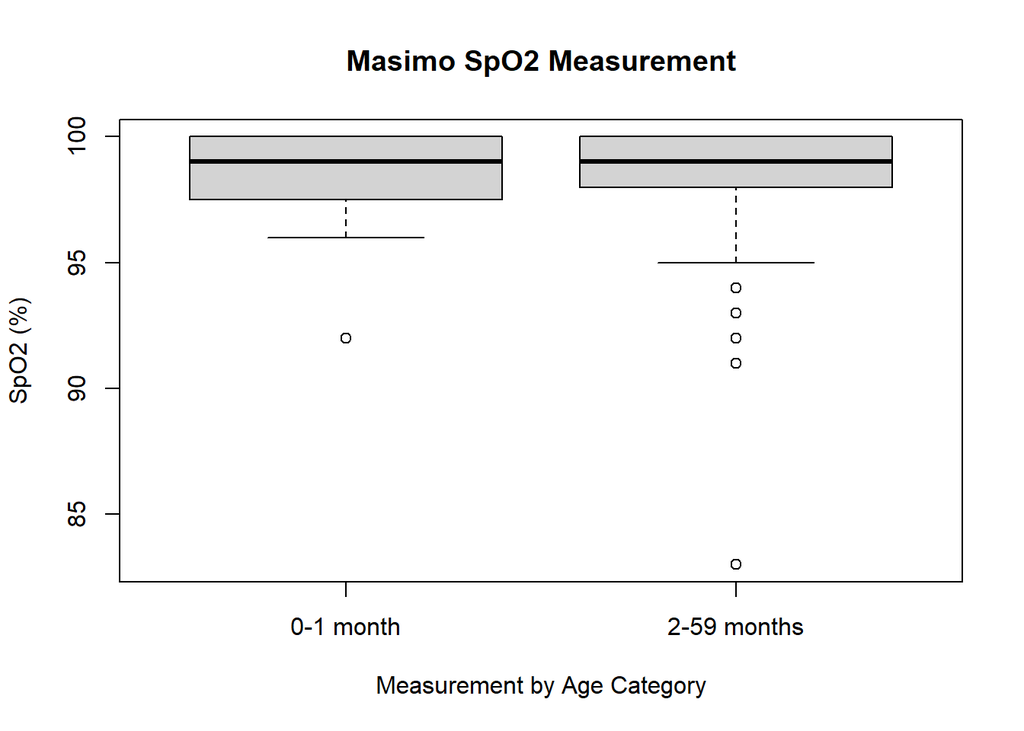

### Pulse Rate

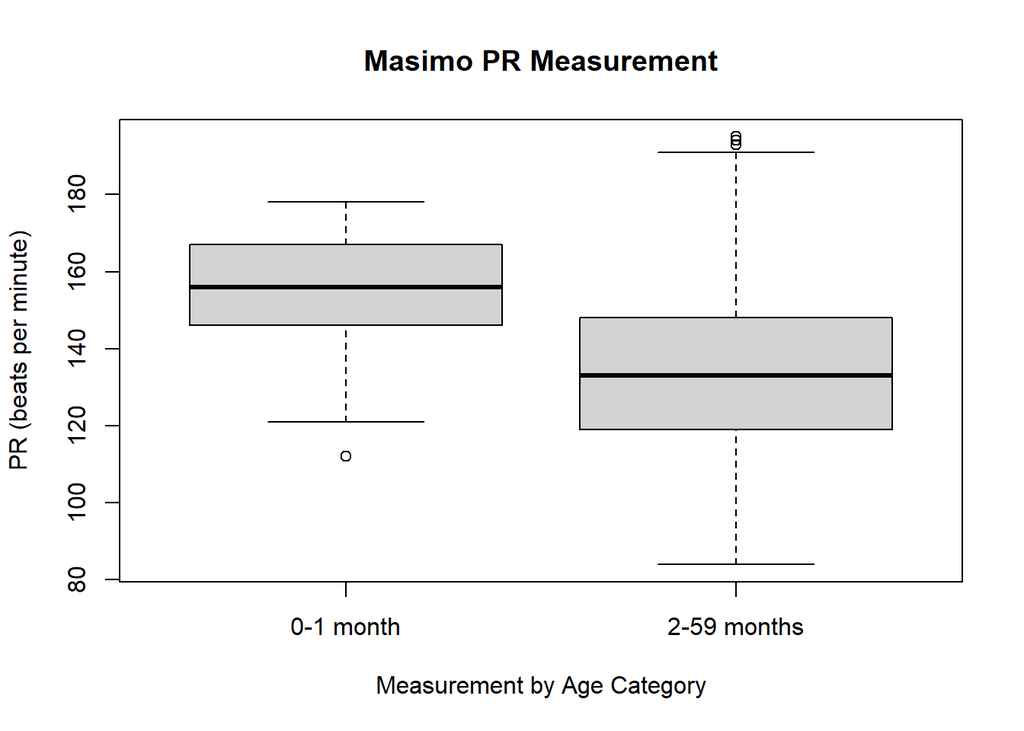

### Respiratory Rate

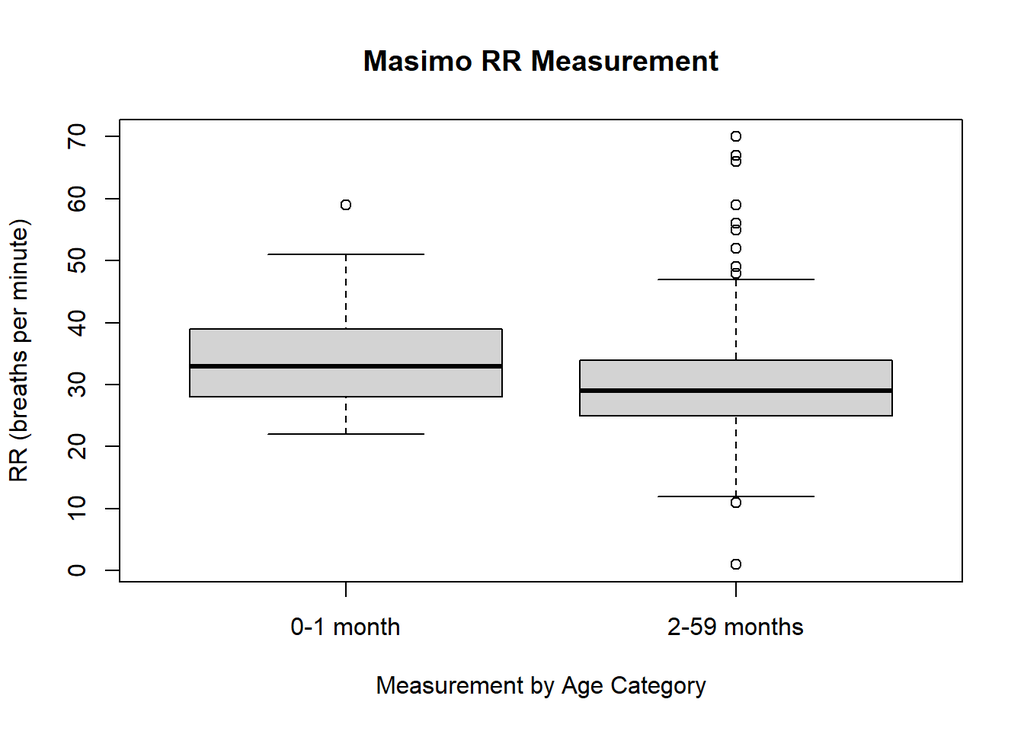

### Temperature

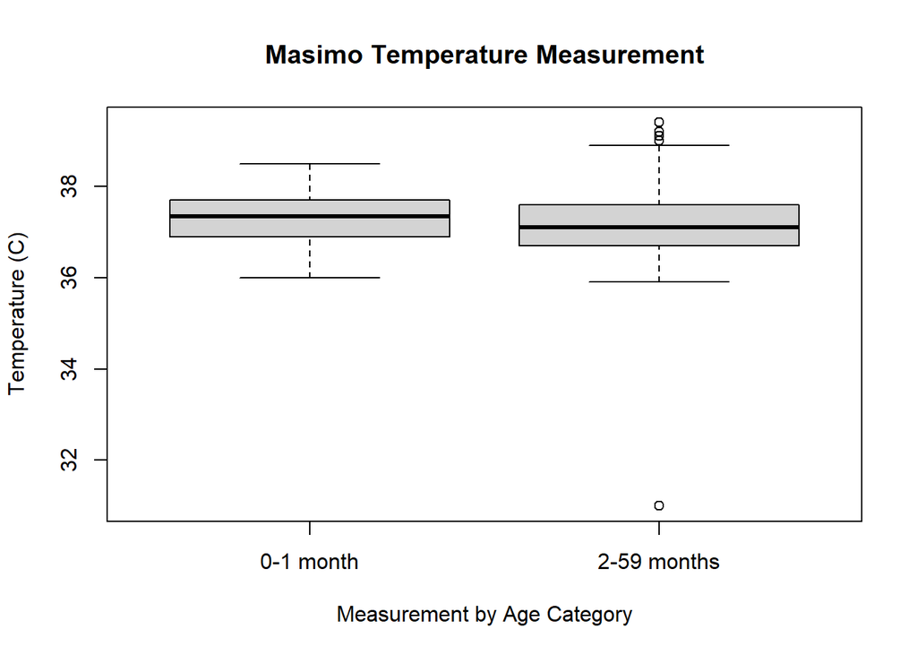

## Tanzania

### SpO2

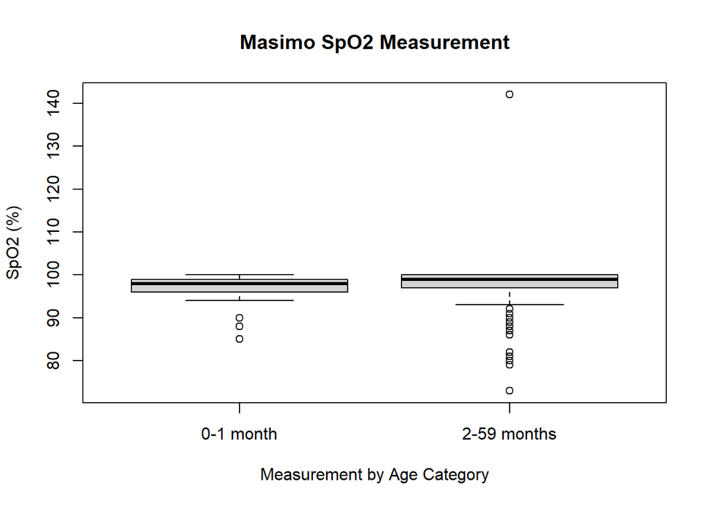

### Pulse Rate

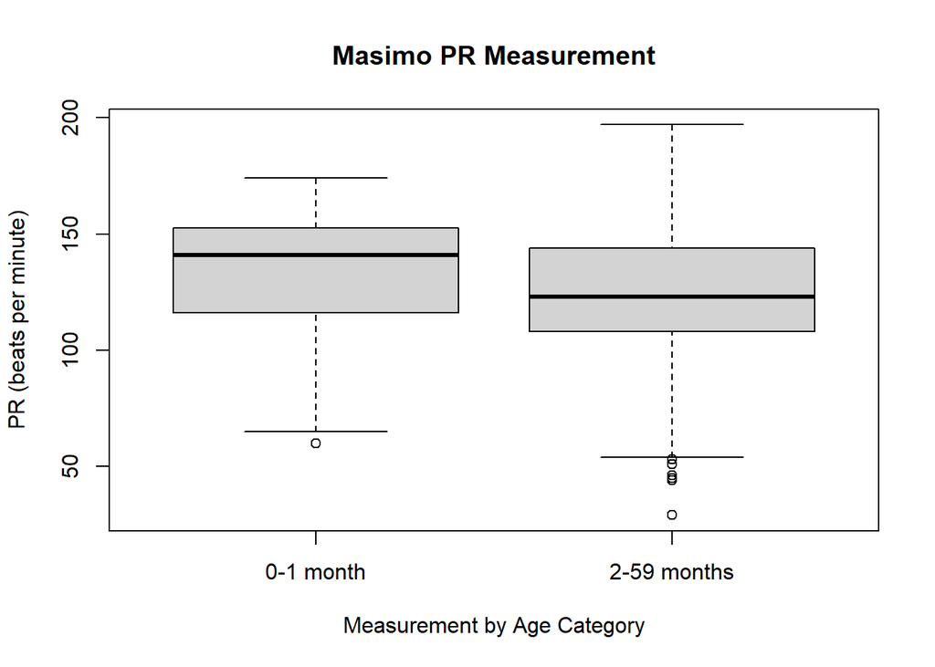

### Respiratory Rate

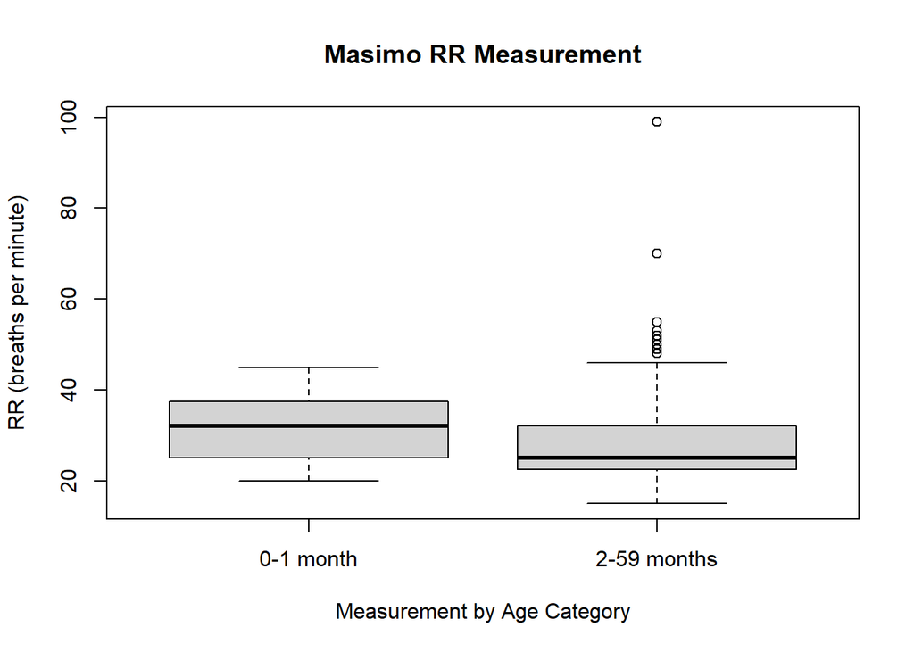

### Temperature

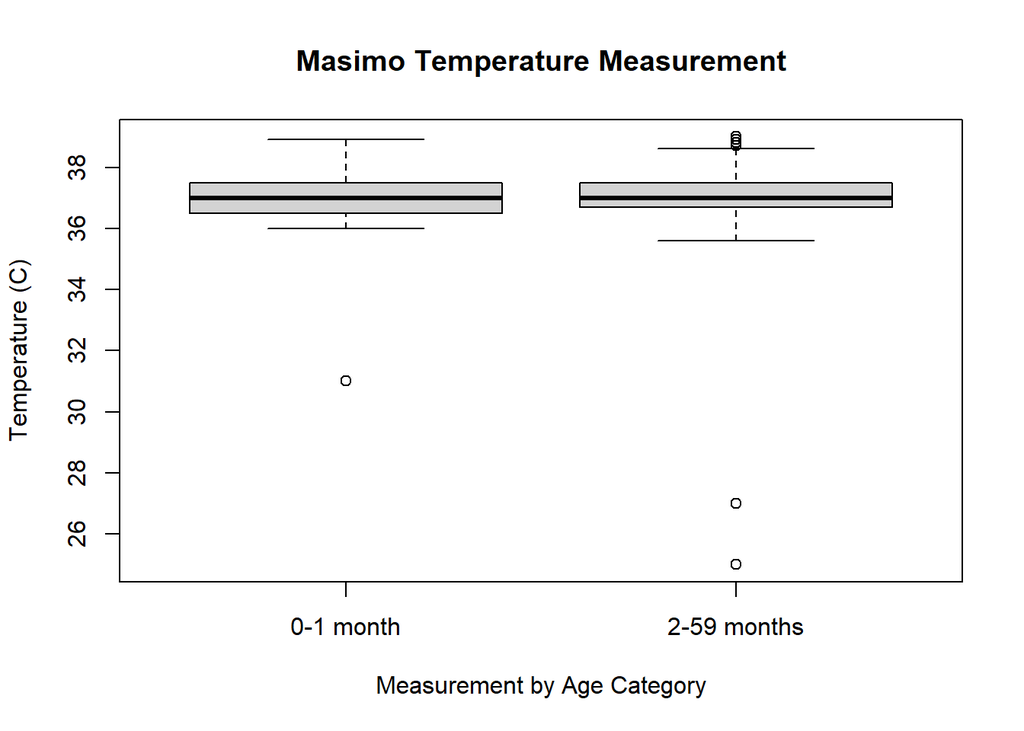

## Kenya

### SpO2

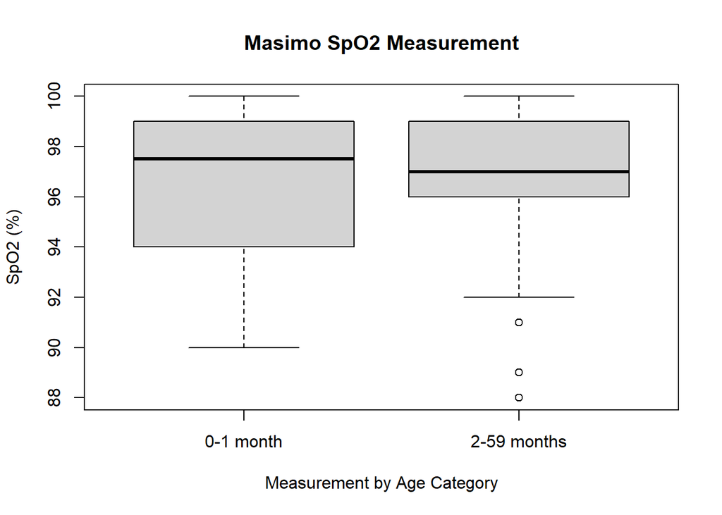

### Pulse Rate

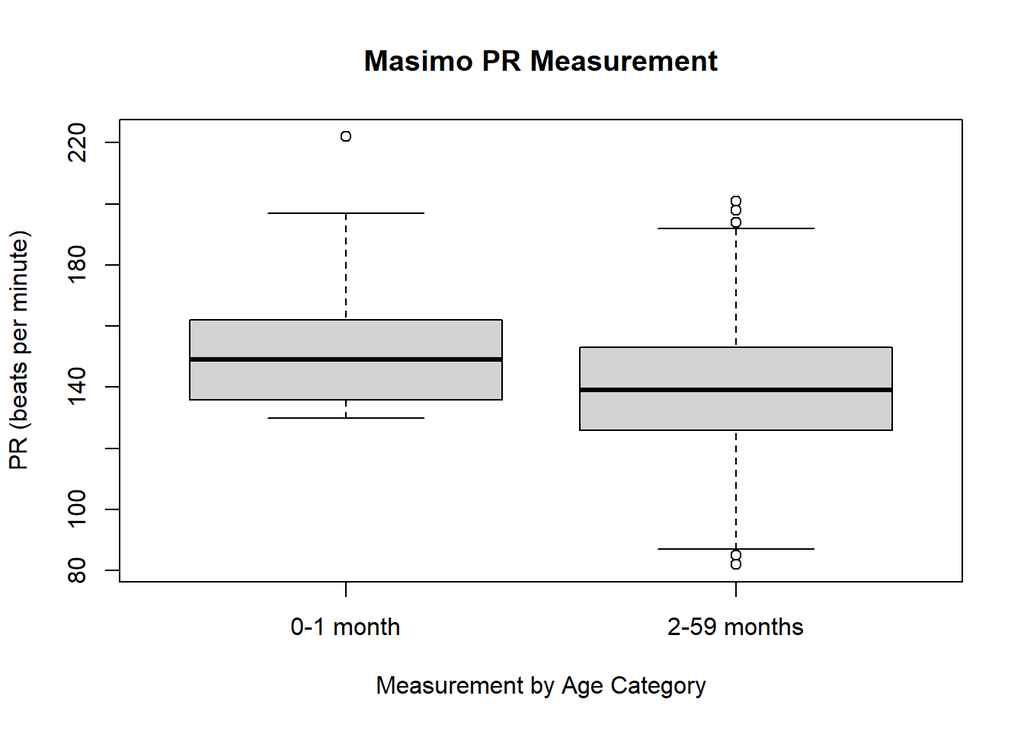

### Respiratory Rate

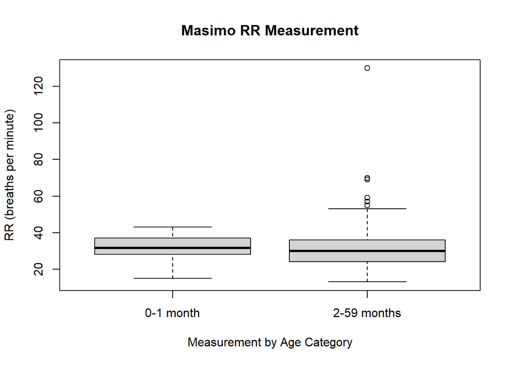

### Temperature

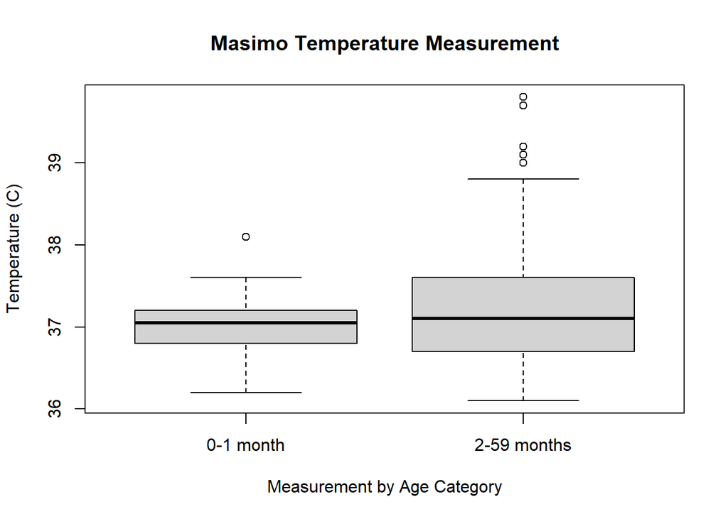